# Risk Factor Analysis

## Outcome Variable

**Outcome Variable:** pers_wasted624

## Predictor Variables

**Intervention Variable:** ever_sstunted06

**Adjustment Set:**

- sex
- arm
- brthmon
- vagbrth
- single
- W_mage
- W_mhtcm
- W_mwtkg
- W_mbmi
- W_meducyrs
- W_feducyrs
- W_parity
- delta_brthmon
- delta_vagbrth
- delta_single
- delta_W_mage
- delta_W_mhtcm
- delta_W_mwtkg
- delta_W_mbmi
- delta_W_meducyrs
- delta_W_feducyrs
- delta_W_parity

## Stratifying Variables

The analysis was stratified on these variable(s):

- studyid
- country

## Data Summary

| studyid | country | ever_sstunted06 | pers_wasted624 | n_cell | n | outcome_variable |
| --- | --- | --- | --- | --- | --- | --- |
| ki0047075b-MAL-ED | BANGLADESH | 0 | 0 | 207 | 240 | pers_wasted624 |
| ki0047075b-MAL-ED | BANGLADESH | 0 | 1 | 15 | 240 | pers_wasted624 |
| ki0047075b-MAL-ED | BANGLADESH | 1 | 0 | 16 | 240 | pers_wasted624 |
| ki0047075b-MAL-ED | BANGLADESH | 1 | 1 | 2 | 240 | pers_wasted624 |
| ki0047075b-MAL-ED | BRAZIL | 0 | 0 | 188 | 207 | pers_wasted624 |
| ki0047075b-MAL-ED | BRAZIL | 0 | 1 | 2 | 207 | pers_wasted624 |
| ki0047075b-MAL-ED | BRAZIL | 1 | 0 | 17 | 207 | pers_wasted624 |
| ki0047075b-MAL-ED | BRAZIL | 1 | 1 | 0 | 207 | pers_wasted624 |
| ki0047075b-MAL-ED | INDIA | 0 | 0 | 193 | 235 | pers_wasted624 |
| ki0047075b-MAL-ED | INDIA | 0 | 1 | 22 | 235 | pers_wasted624 |
| ki0047075b-MAL-ED | INDIA | 1 | 0 | 14 | 235 | pers_wasted624 |
| ki0047075b-MAL-ED | INDIA | 1 | 1 | 6 | 235 | pers_wasted624 |
| ki0047075b-MAL-ED | NEPAL | 0 | 0 | 224 | 235 | pers_wasted624 |
| ki0047075b-MAL-ED | NEPAL | 0 | 1 | 1 | 235 | pers_wasted624 |
| ki0047075b-MAL-ED | NEPAL | 1 | 0 | 9 | 235 | pers_wasted624 |
| ki0047075b-MAL-ED | NEPAL | 1 | 1 | 1 | 235 | pers_wasted624 |
| ki0047075b-MAL-ED | PERU | 0 | 0 | 234 | 270 | pers_wasted624 |
| ki0047075b-MAL-ED | PERU | 0 | 1 | 1 | 270 | pers_wasted624 |
| ki0047075b-MAL-ED | PERU | 1 | 0 | 33 | 270 | pers_wasted624 |
| ki0047075b-MAL-ED | PERU | 1 | 1 | 2 | 270 | pers_wasted624 |
| ki0047075b-MAL-ED | SOUTH AFRICA | 0 | 0 | 230 | 259 | pers_wasted624 |
| ki0047075b-MAL-ED | SOUTH AFRICA | 0 | 1 | 2 | 259 | pers_wasted624 |
| ki0047075b-MAL-ED | SOUTH AFRICA | 1 | 0 | 27 | 259 | pers_wasted624 |
| ki0047075b-MAL-ED | SOUTH AFRICA | 1 | 1 | 0 | 259 | pers_wasted624 |
| ki0047075b-MAL-ED | TANZANIA, UNITED REPUBLIC OF | 0 | 0 | 208 | 245 | pers_wasted624 |
| ki0047075b-MAL-ED | TANZANIA, UNITED REPUBLIC OF | 0 | 1 | 0 | 245 | pers_wasted624 |
| ki0047075b-MAL-ED | TANZANIA, UNITED REPUBLIC OF | 1 | 0 | 37 | 245 | pers_wasted624 |
| ki0047075b-MAL-ED | TANZANIA, UNITED REPUBLIC OF | 1 | 1 | 0 | 245 | pers_wasted624 |
| ki1000108-CMC-V-BCS-2002 | INDIA | 0 | 0 | 260 | 370 | pers_wasted624 |
| ki1000108-CMC-V-BCS-2002 | INDIA | 0 | 1 | 16 | 370 | pers_wasted624 |

[output cut: 90 more lines]

The following strata were considered:

- studyid: ki0047075b-MAL-ED, country: BANGLADESH
- studyid: ki0047075b-MAL-ED, country: BRAZIL
- studyid: ki0047075b-MAL-ED, country: INDIA
- studyid: ki0047075b-MAL-ED, country: NEPAL
- studyid: ki0047075b-MAL-ED, country: PERU
- studyid: ki0047075b-MAL-ED, country: SOUTH AFRICA
- studyid: ki0047075b-MAL-ED, country: TANZANIA, UNITED REPUBLIC OF
- studyid: ki1000108-CMC-V-BCS-2002, country: INDIA
- studyid: ki1000108-IRC, country: INDIA
- studyid: ki1000109-EE, country: PAKISTAN
- studyid: ki1000109-ResPak, country: PAKISTAN
- studyid: ki1000304b-SAS-CompFeed, country: INDIA
- studyid: ki1000304b-SAS-FoodSuppl, country: INDIA
- studyid: ki1017093-NIH-Birth, country: BANGLADESH
- studyid: ki1017093b-PROVIDE, country: BANGLADESH
- studyid: ki1017093c-NIH-Crypto, country: BANGLADESH
- studyid: ki1066203-TanzaniaChild2, country: TANZANIA, UNITED REPUBLIC OF
- studyid: ki1101329-Keneba, country: GAMBIA
- studyid: ki1112895-Guatemala BSC, country: GUATEMALA
- studyid: ki1113344-GMS-Nepal, country: NEPAL
- studyid: ki1114097-CMIN, country: BANGLADESH
- studyid: ki1114097-CONTENT, country: PERU
- studyid: ki1119695-PROBIT, country: BELARUS
- studyid: ki1126311-ZVITAMBO, country: ZIMBABWE
- studyid: ki1135781-COHORTS, country: GUATEMALA
- studyid: ki1135781-COHORTS, country: INDIA
- studyid: ki1135781-COHORTS, country: PHILIPPINES
- studyid: ki1148112-LCNI-5, country: MALAWI
- studyid: kiGH5241-JiVitA-3, country: BANGLADESH
- studyid: kiGH5241-JiVitA-4, country: BANGLADESH

### Dropped Strata

Some strata were dropped due to rare outcomes:

- studyid: ki0047075b-MAL-ED, country: BANGLADESH
- studyid: ki0047075b-MAL-ED, country: BRAZIL
- studyid: ki0047075b-MAL-ED, country: NEPAL
- studyid: ki0047075b-MAL-ED, country: PERU
- studyid: ki0047075b-MAL-ED, country: SOUTH AFRICA
- studyid: ki0047075b-MAL-ED, country: TANZANIA, UNITED REPUBLIC OF
- studyid: ki1017093b-PROVIDE, country: BANGLADESH
- studyid: ki1112895-Guatemala BSC, country: GUATEMALA
- studyid: ki1114097-CONTENT, country: PERU
- studyid: ki1119695-PROBIT, country: BELARUS
- studyid: ki1148112-LCNI-5, country: MALAWI

## Methods Detail

We’re interested in the causal parameters $E[Y_a]$ for all values of $a \in \mathcal{A}$. These parameters represent the mean outcome if, possibly contrary to fact, we intervened to set all units to have $A=a$. Under the randomization and positivity assumptions, these are identified by the statistical parameters $\psi_a=E_W[E_{Y|A,W}(Y|A=a,W)]$. In addition, we’re interested in the mean of $Y$, $E[Y]$ under no intervention (the observed mean). We will estimate these parameters by using SuperLearner to fit the relevant likelihood factors – $E_{Y|A,W}(Y|A=a,W)$ and $p(A=a|W)$, and then updating our likelihood fit using a joint TMLE.

For unadjusted analyses ($W=\{\}$), initial likelihoods were estimated using Lrnr_glm to estimate the simple $E(Y|A)$ and Lrnr_mean to estimate $p(A)$. For adjusted analyses, a small library containing Lrnr_glmnet, Lrnr_xgboost, and Lrnr_mean was used.

Having estimated these parameters, we will then use the delta method to estimate relative risks and attributable risks relative to a prespecified baseline level of $A$.

# Results Detail

## Results Plots

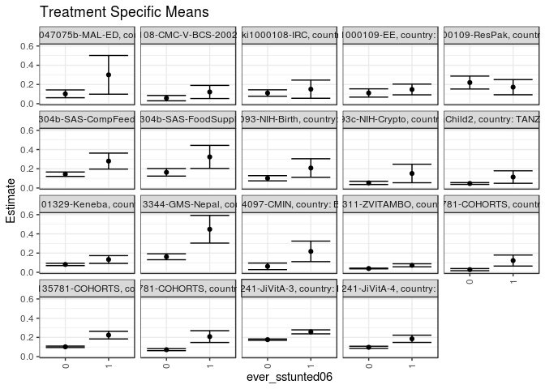

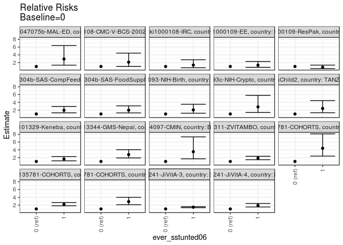

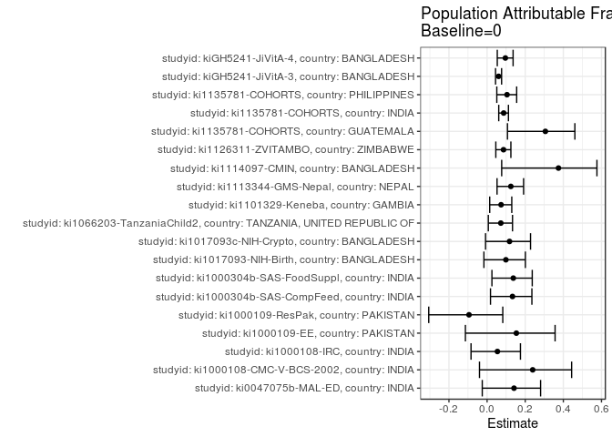

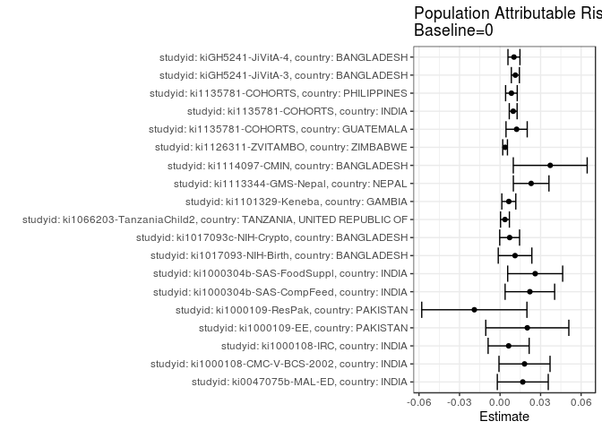

## Results Table

### Parameter: TSM

| studyid | country | intervention_level | baseline_level | estimate | ci_lower | ci_upper |
| --- | --- | --- | --- | --- | --- | --- |
| ki0047075b-MAL-ED | INDIA | 0 | NA | 0.1023256 | 0.0617274 | 0.1429237 |
| ki0047075b-MAL-ED | INDIA | 1 | NA | 0.3000000 | 0.0987348 | 0.5012652 |
| ki1000108-CMC-V-BCS-2002 | INDIA | 0 | NA | 0.0575688 | 0.0297908 | 0.0853467 |
| ki1000108-CMC-V-BCS-2002 | INDIA | 1 | NA | 0.1218560 | 0.0536809 | 0.1900311 |
| ki1000108-IRC | INDIA | 0 | NA | 0.1107233 | 0.0773688 | 0.1440778 |
| ki1000108-IRC | INDIA | 1 | NA | 0.1507382 | 0.0561218 | 0.2453546 |
| ki1000109-EE | PAKISTAN | 0 | NA | 0.1111987 | 0.0681744 | 0.1542230 |
| ki1000109-EE | PAKISTAN | 1 | NA | 0.1478488 | 0.0919819 | 0.2037156 |
| ki1000109-ResPak | PAKISTAN | 0 | NA | 0.2198908 | 0.1526234 | 0.2871581 |
| ki1000109-ResPak | PAKISTAN | 1 | NA | 0.1717465 | 0.0927164 | 0.2507766 |
| ki1000304b-SAS-CompFeed | INDIA | 0 | NA | 0.1436339 | 0.1206548 | 0.1666129 |
| ki1000304b-SAS-CompFeed | INDIA | 1 | NA | 0.2799046 | 0.1968329 | 0.3629762 |
| ki1000304b-SAS-FoodSuppl | INDIA | 0 | NA | 0.1630511 | 0.1235549 | 0.2025474 |
| ki1000304b-SAS-FoodSuppl | INDIA | 1 | NA | 0.3234403 | 0.2036326 | 0.4432479 |
| ki1017093-NIH-Birth | BANGLADESH | 0 | NA | 0.1014482 | 0.0743174 | 0.1285790 |
| ki1017093-NIH-Birth | BANGLADESH | 1 | NA | 0.2081387 | 0.1117821 | 0.3044954 |
| ki1017093c-NIH-Crypto | BANGLADESH | 0 | NA | 0.0531758 | 0.0362619 | 0.0700896 |
| ki1017093c-NIH-Crypto | BANGLADESH | 1 | NA | 0.1509434 | 0.0544976 | 0.2473892 |
| ki1066203-TanzaniaChild2 | TANZANIA, UNITED REPUBLIC OF | 0 | NA | 0.0469028 | 0.0374361 | 0.0563696 |
| ki1066203-TanzaniaChild2 | TANZANIA, UNITED REPUBLIC OF | 1 | NA | 0.1137010 | 0.0487696 | 0.1786324 |
| ki1101329-Keneba | GAMBIA | 0 | NA | 0.0818141 | 0.0698639 | 0.0937642 |
| ki1101329-Keneba | GAMBIA | 1 | NA | 0.1332039 | 0.0927812 | 0.1736266 |
| ki1113344-GMS-Nepal | NEPAL | 0 | NA | 0.1617271 | 0.1306777 | 0.1927766 |
| ki1113344-GMS-Nepal | NEPAL | 1 | NA | 0.4479785 | 0.3038139 | 0.5921430 |
| ki1114097-CMIN | BANGLADESH | 0 | NA | 0.0620626 | 0.0279182 | 0.0962071 |
| ki1114097-CMIN | BANGLADESH | 1 | NA | 0.2177520 | 0.1109239 | 0.3245800 |
| ki1126311-ZVITAMBO | ZIMBABWE | 0 | NA | 0.0395075 | 0.0356141 | 0.0434009 |
| ki1126311-ZVITAMBO | ZIMBABWE | 1 | NA | 0.0727179 | 0.0569695 | 0.0884664 |
| ki1135781-COHORTS | GUATEMALA | 0 | NA | 0.0278200 | 0.0168096 | 0.0388304 |
| ki1135781-COHORTS | GUATEMALA | 1 | NA | 0.1224889 | 0.0651666 | 0.1798112 |
| ki1135781-COHORTS | INDIA | 0 | NA | 0.1021261 | 0.0946960 | 0.1095561 |
| ki1135781-COHORTS | INDIA | 1 | NA | 0.2240040 | 0.1839009 | 0.2641071 |
| ki1135781-COHORTS | PHILIPPINES | 0 | NA | 0.0720407 | 0.0620613 | 0.0820201 |
| ki1135781-COHORTS | PHILIPPINES | 1 | NA | 0.2084492 | 0.1472252 | 0.2696732 |
| kiGH5241-JiVitA-3 | BANGLADESH | 0 | NA | 0.1764421 | 0.1694820 | 0.1834021 |
| kiGH5241-JiVitA-3 | BANGLADESH | 1 | NA | 0.2574621 | 0.2366892 | 0.2782349 |
| kiGH5241-JiVitA-4 | BANGLADESH | 0 | NA | 0.0969994 | 0.0859591 | 0.1080397 |
| kiGH5241-JiVitA-4 | BANGLADESH | 1 | NA | 0.1854338 | 0.1476826 | 0.2231849 |

### Parameter: E(Y)

| studyid | country | intervention_level | baseline_level | estimate | ci_lower | ci_upper |
| --- | --- | --- | --- | --- | --- | --- |
| ki0047075b-MAL-ED | INDIA | NA | NA | 0.1191489 | 0.0776405 | 0.1606574 |
| ki1000108-CMC-V-BCS-2002 | INDIA | NA | NA | 0.0756757 | 0.0486905 | 0.1026609 |
| ki1000108-IRC | INDIA | NA | NA | 0.1170732 | 0.0859146 | 0.1482317 |
| ki1000109-EE | PAKISTAN | NA | NA | 0.1313673 | 0.0970401 | 0.1656945 |
| ki1000109-ResPak | PAKISTAN | NA | NA | 0.2008547 | 0.1494120 | 0.2522974 |
| ki1000304b-SAS-CompFeed | INDIA | NA | NA | 0.1657061 | 0.1471754 | 0.1842367 |
| ki1000304b-SAS-FoodSuppl | INDIA | NA | NA | 0.1890547 | 0.1507312 | 0.2273783 |
| ki1017093-NIH-Birth | BANGLADESH | NA | NA | 0.1125461 | 0.0859151 | 0.1391771 |
| ki1017093c-NIH-Crypto | BANGLADESH | NA | NA | 0.0602740 | 0.0429977 | 0.0775502 |
| ki1066203-TanzaniaChild2 | TANZANIA, UNITED REPUBLIC OF | NA | NA | 0.0505451 | 0.0409848 | 0.0601054 |
| ki1101329-Keneba | GAMBIA | NA | NA | 0.0882993 | 0.0766987 | 0.0998998 |
| ki1113344-GMS-Nepal | NEPAL | NA | NA | 0.1847458 | 0.1534039 | 0.2160876 |
| ki1114097-CMIN | BANGLADESH | NA | NA | 0.0992063 | 0.0622241 | 0.1361886 |
| ki1126311-ZVITAMBO | ZIMBABWE | NA | NA | 0.0432327 | 0.0393972 | 0.0470683 |
| ki1135781-COHORTS | GUATEMALA | NA | NA | 0.0400782 | 0.0280529 | 0.0521035 |
| ki1135781-COHORTS | INDIA | NA | NA | 0.1118526 | 0.1044114 | 0.1192938 |
| ki1135781-COHORTS | PHILIPPINES | NA | NA | 0.0804557 | 0.0703953 | 0.0905161 |
| kiGH5241-JiVitA-3 | BANGLADESH | NA | NA | 0.1877787 | 0.1812440 | 0.1943134 |
| kiGH5241-JiVitA-4 | BANGLADESH | NA | NA | 0.1072855 | 0.0967458 | 0.1178252 |

### Parameter: RR

| studyid | country | intervention_level | baseline_level | estimate | ci_lower | ci_upper |
| --- | --- | --- | --- | --- | --- | --- |
| ki0047075b-MAL-ED | INDIA | 0 | 0 | 1.0000000 | 1.0000000 | 1.000000 |
| ki0047075b-MAL-ED | INDIA | 1 | 0 | 2.9318182 | 1.3447391 | 6.391989 |
| ki1000108-CMC-V-BCS-2002 | INDIA | 0 | 0 | 1.0000000 | 1.0000000 | 1.000000 |
| ki1000108-CMC-V-BCS-2002 | INDIA | 1 | 0 | 2.1167023 | 1.0083403 | 4.443369 |
| ki1000108-IRC | INDIA | 0 | 0 | 1.0000000 | 1.0000000 | 1.000000 |
| ki1000108-IRC | INDIA | 1 | 0 | 1.3613955 | 0.6781160 | 2.733157 |
| ki1000109-EE | PAKISTAN | 0 | 0 | 1.0000000 | 1.0000000 | 1.000000 |
| ki1000109-EE | PAKISTAN | 1 | 0 | 1.3295909 | 0.7725042 | 2.288417 |
| ki1000109-ResPak | PAKISTAN | 0 | 0 | 1.0000000 | 1.0000000 | 1.000000 |
| ki1000109-ResPak | PAKISTAN | 1 | 0 | 0.7810537 | 0.4504103 | 1.354421 |
| ki1000304b-SAS-CompFeed | INDIA | 0 | 0 | 1.0000000 | 1.0000000 | 1.000000 |
| ki1000304b-SAS-CompFeed | INDIA | 1 | 0 | 1.9487365 | 1.2936787 | 2.935485 |
| ki1000304b-SAS-FoodSuppl | INDIA | 0 | 0 | 1.0000000 | 1.0000000 | 1.000000 |
| ki1000304b-SAS-FoodSuppl | INDIA | 1 | 0 | 1.9836742 | 1.2735205 | 3.089831 |
| ki1017093-NIH-Birth | BANGLADESH | 0 | 0 | 1.0000000 | 1.0000000 | 1.000000 |
| ki1017093-NIH-Birth | BANGLADESH | 1 | 0 | 2.0516753 | 1.2020280 | 3.501892 |
| ki1017093c-NIH-Crypto | BANGLADESH | 0 | 0 | 1.0000000 | 1.0000000 | 1.000000 |
| ki1017093c-NIH-Crypto | BANGLADESH | 1 | 0 | 2.8385744 | 1.3903512 | 5.795302 |
| ki1066203-TanzaniaChild2 | TANZANIA, UNITED REPUBLIC OF | 0 | 0 | 1.0000000 | 1.0000000 | 1.000000 |
| ki1066203-TanzaniaChild2 | TANZANIA, UNITED REPUBLIC OF | 1 | 0 | 2.4241812 | 1.3227508 | 4.442752 |
| ki1101329-Keneba | GAMBIA | 0 | 0 | 1.0000000 | 1.0000000 | 1.000000 |
| ki1101329-Keneba | GAMBIA | 1 | 0 | 1.6281292 | 1.1638907 | 2.277538 |
| ki1113344-GMS-Nepal | NEPAL | 0 | 0 | 1.0000000 | 1.0000000 | 1.000000 |
| ki1113344-GMS-Nepal | NEPAL | 1 | 0 | 2.7699647 | 1.9056141 | 4.026368 |
| ki1114097-CMIN | BANGLADESH | 0 | 0 | 1.0000000 | 1.0000000 | 1.000000 |
| ki1114097-CMIN | BANGLADESH | 1 | 0 | 3.5085840 | 1.6767558 | 7.341654 |
| ki1126311-ZVITAMBO | ZIMBABWE | 0 | 0 | 1.0000000 | 1.0000000 | 1.000000 |
| ki1126311-ZVITAMBO | ZIMBABWE | 1 | 0 | 1.8406113 | 1.4511623 | 2.334577 |
| ki1135781-COHORTS | GUATEMALA | 0 | 0 | 1.0000000 | 1.0000000 | 1.000000 |
| ki1135781-COHORTS | GUATEMALA | 1 | 0 | 4.4029068 | 2.3899578 | 8.111268 |
| ki1135781-COHORTS | INDIA | 0 | 0 | 1.0000000 | 1.0000000 | 1.000000 |
| ki1135781-COHORTS | INDIA | 1 | 0 | 2.1934071 | 1.8083806 | 2.660410 |
| ki1135781-COHORTS | PHILIPPINES | 0 | 0 | 1.0000000 | 1.0000000 | 1.000000 |
| ki1135781-COHORTS | PHILIPPINES | 1 | 0 | 2.8934914 | 2.0917421 | 4.002546 |
| kiGH5241-JiVitA-3 | BANGLADESH | 0 | 0 | 1.0000000 | 1.0000000 | 1.000000 |
| kiGH5241-JiVitA-3 | BANGLADESH | 1 | 0 | 1.4591877 | 1.3347507 | 1.595226 |
| kiGH5241-JiVitA-4 | BANGLADESH | 0 | 0 | 1.0000000 | 1.0000000 | 1.000000 |
| kiGH5241-JiVitA-4 | BANGLADESH | 1 | 0 | 1.9117002 | 1.5091418 | 2.421640 |

### Parameter: PAR

| studyid | country | intervention_level | baseline_level | estimate | ci_lower | ci_upper |
| --- | --- | --- | --- | --- | --- | --- |
| ki0047075b-MAL-ED | INDIA | 0 | NA | 0.0168234 | -0.0020257 | 0.0356724 |
| ki1000108-CMC-V-BCS-2002 | INDIA | 0 | NA | 0.0181069 | -0.0007895 | 0.0370033 |
| ki1000108-IRC | INDIA | 0 | NA | 0.0063499 | -0.0088403 | 0.0215400 |
| ki1000109-EE | PAKISTAN | 0 | NA | 0.0201686 | -0.0105727 | 0.0509099 |
| ki1000109-ResPak | PAKISTAN | 0 | NA | -0.0190361 | -0.0579739 | 0.0199018 |
| ki1000304b-SAS-CompFeed | INDIA | 0 | NA | 0.0220722 | 0.0037418 | 0.0404026 |
| ki1000304b-SAS-FoodSuppl | INDIA | 0 | NA | 0.0260036 | 0.0056549 | 0.0463523 |
| ki1017093-NIH-Birth | BANGLADESH | 0 | NA | 0.0110979 | -0.0013366 | 0.0235324 |
| ki1017093c-NIH-Crypto | BANGLADESH | 0 | NA | 0.0070982 | -0.0002455 | 0.0144419 |
| ki1066203-TanzaniaChild2 | TANZANIA, UNITED REPUBLIC OF | 0 | NA | 0.0036422 | 0.0003708 | 0.0069136 |
| ki1101329-Keneba | GAMBIA | 0 | NA | 0.0064852 | 0.0013194 | 0.0116510 |
| ki1113344-GMS-Nepal | NEPAL | 0 | NA | 0.0230186 | 0.0098448 | 0.0361924 |
| ki1114097-CMIN | BANGLADESH | 0 | NA | 0.0371437 | 0.0097971 | 0.0644904 |
| ki1126311-ZVITAMBO | ZIMBABWE | 0 | NA | 0.0037252 | 0.0019855 | 0.0054650 |
| ki1135781-COHORTS | GUATEMALA | 0 | NA | 0.0122582 | 0.0044086 | 0.0201078 |
| ki1135781-COHORTS | INDIA | 0 | NA | 0.0097265 | 0.0068251 | 0.0126280 |
| ki1135781-COHORTS | PHILIPPINES | 0 | NA | 0.0084150 | 0.0041080 | 0.0127219 |
| kiGH5241-JiVitA-3 | BANGLADESH | 0 | NA | 0.0113367 | 0.0083583 | 0.0143151 |
| kiGH5241-JiVitA-4 | BANGLADESH | 0 | NA | 0.0102861 | 0.0058550 | 0.0147173 |

### Parameter: PAF

| studyid | country | intervention_level | baseline_level | estimate | ci_lower | ci_upper |
| --- | --- | --- | --- | --- | --- | --- |
| ki0047075b-MAL-ED | INDIA | 0 | NA | 0.1411960 | -0.0253403 | 0.2806834 |
| ki1000108-CMC-V-BCS-2002 | INDIA | 0 | NA | 0.2392696 | -0.0398275 | 0.4434550 |
| ki1000108-IRC | INDIA | 0 | NA | 0.0542385 | -0.0841942 | 0.1749957 |
| ki1000109-EE | PAKISTAN | 0 | NA | 0.1535284 | -0.1137309 | 0.3566542 |
| ki1000109-ResPak | PAKISTAN | 0 | NA | -0.0947752 | -0.3060520 | 0.0823238 |
| ki1000304b-SAS-CompFeed | INDIA | 0 | NA | 0.1332008 | 0.0178675 | 0.2349903 |
| ki1000304b-SAS-FoodSuppl | INDIA | 0 | NA | 0.1375455 | 0.0253754 | 0.2368058 |
| ki1017093-NIH-Birth | BANGLADESH | 0 | NA | 0.0986079 | -0.0166105 | 0.2007680 |
| ki1017093c-NIH-Crypto | BANGLADESH | 0 | NA | 0.1177655 | -0.0080550 | 0.2278818 |
| ki1066203-TanzaniaChild2 | TANZANIA, UNITED REPUBLIC OF | 0 | NA | 0.0720593 | 0.0064171 | 0.1333648 |
| ki1101329-Keneba | GAMBIA | 0 | NA | 0.0734456 | 0.0137947 | 0.1294886 |
| ki1113344-GMS-Nepal | NEPAL | 0 | NA | 0.1245962 | 0.0522535 | 0.1914168 |
| ki1114097-CMIN | BANGLADESH | 0 | NA | 0.3744087 | 0.0765861 | 0.5761765 |
| ki1126311-ZVITAMBO | ZIMBABWE | 0 | NA | 0.0861671 | 0.0458189 | 0.1248091 |
| ki1135781-COHORTS | GUATEMALA | 0 | NA | 0.3058569 | 0.1069205 | 0.4604795 |
| ki1135781-COHORTS | INDIA | 0 | NA | 0.0869586 | 0.0611713 | 0.1120376 |
| ki1135781-COHORTS | PHILIPPINES | 0 | NA | 0.1045913 | 0.0509828 | 0.1551715 |
| kiGH5241-JiVitA-3 | BANGLADESH | 0 | NA | 0.0603726 | 0.0444070 | 0.0760715 |
| kiGH5241-JiVitA-4 | BANGLADESH | 0 | NA | 0.0958761 | 0.0534241 | 0.1364242 |